# Planificación de Encuestas

2/8/2019

## Deserción estudiantil

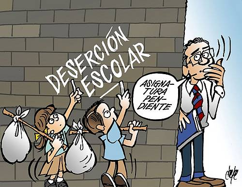

## Nuestro propósito

## Objetivos

[figure not shown]

- Generar alertas tempranas acerca de la deserción universitaria, basados en percepción de estudiantes activos.
- Implementar técnicas de Aprendizaje Automático (*Machine Learning*) para conocer y caracterizar posibles factores de incidencia sobre la deserción estudiantil.

## Planificación de encuestas

## Estudio y planteamiento

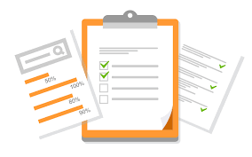

- Establecimiento de objetivos
  - Objetivos primarios
  - Objetivos secundarios
- Estudio de fuentes estadísticas y metodológicas
- Planificación operacional y diseño del método de muestreo

## Definición de variables: preguntas

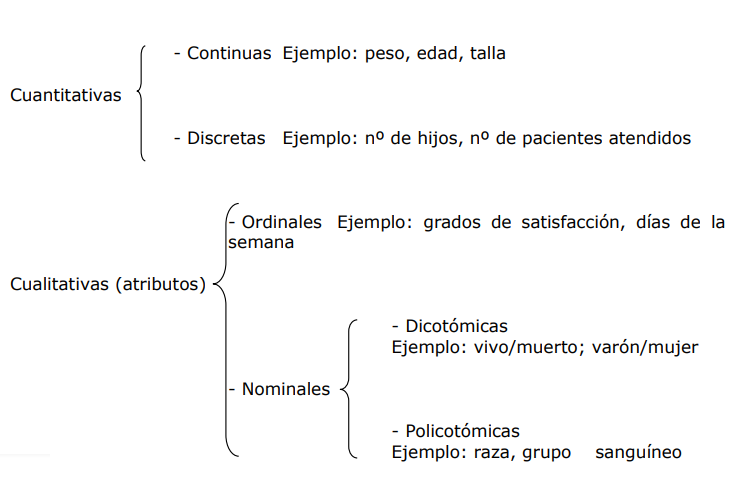

## Muestreo

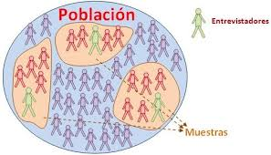

- **Objetivo:** las técnicas de muestreo proporcionan elementos que permiten conocer características, atributos o tendencias referidas al total de unidades de un conjunto (universidad, país, barrio, comuna, etc), analizando sólo un fragmento de las unidades de la población.

## Conceptos

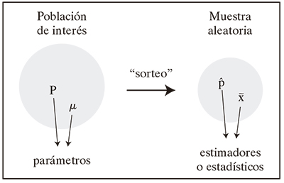

- **Parámetro:** valor poblacional de una variable sobre la cual se tiene interés (siempre desconocido).
- **Estadístico:** valor estimado de una variable a partir de una muestra.
- **Error muestral:** diferencia o desvío entre el estadístico y el parámetro.
- **Nivel de confianza:** probabilidad que mide el ajuste de la estimación a la realidad.
- **Varianza:** medida de variabilidad de los estadísticos.

## Tamaño de muestra

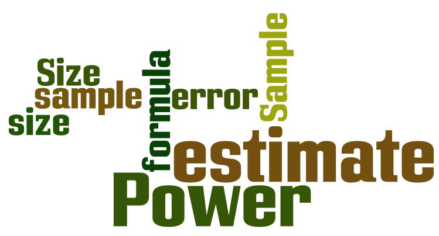

- El tamaño de la muestra está asociado con el tipo de muestreo a emplear, con la frecuencia que se desea medir, con la heterogeneidad o dispersión del fenómeno bajo estudio y con el error o fiabilidad mínima que se está dispuesto a soportar.
- Los tamaño de muestra pueden estar direccionados a:
  - Estimar la proporción de casos exitosos en una población.
  - Estimar la media (parámetro) de determinada variable objeto de estudio.

## Tamaño de muestra - Proporción

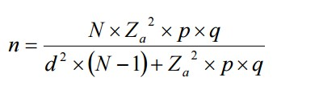

- **Calculadoras online de tamaños muestrales para estimar una proporción:**
  - [Calculadora 1.](http://www.datakey.galeon.com/muestra.html)
  - [Calculadora 2.](https://es.surveymonkey.com/mp/sample-size-calculator/)
  - [Calculadora 3.](https://www.questionpro.com/es/calculadora-de-muestra.html)
  - [Calculadora 4.](https://www.netquest.com/es/gracias-calculadora-muestra)

## Actividad

[figure not shown]

- **¿Podemos nosotros crear nuestra propia calculadora?**
- **¿Qué tal si usamos R para ello?**

## Tipos de muestreo

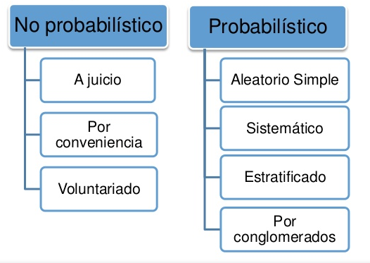

## Metodología

## Metodología tentativa

- Planificación de encuesta.
  - Preguntas (cualitativas, cuantitativas).
  - Tamaño poblacional –> Tamaño muestral
  - Asignación de encuestadores.
  - Recolección y tabulación de información.
- Análisis de resultados:
  - Análisis exploratorio de datos –> Implementación de técnicas multivariadas.
    - Análisis de Componentes Principales (ACP).
    - Análisis de Clúster.
    - Análisis de Correspondencias.
  - Uso de algoritmos de Aprendizaje Automático para generación de alertas tempranas sobre posibles causas de deserción estudiantil.

## Referencias (Español)

- [Artículo U de Caldas.](http://www.scielo.org.co/pdf/rcde/n70/n70a15.pdf)
- [Perfil desertor UNAL Bogotá.](http://pgd2021.unal.edu.co/toolkits/Reto%207%20-Perfil%20desertor%20en%20la%20UN%20Sede%20Bogot%C3%A1.pdf)
- [Deserción estudiantil: UNAL Bogotá.](http://estadisticas.unal.edu.co/fileadmin/user_upload/Desercion_academica_PEAMA.pdf)
- [Factores que inciden en el retiro universitario - UNAL Palmira.](http://bdigital.unal.edu.co/57255/1/20181082657457.pdf)
- [Encuesta nacional de deserción escolar.](http://www.institutodeestudiosurbanos.info/MEN_479_2012/MEN/TQE_Primera%20Fase%202012/Documentos%20de%20base%20MEN/Informes_Ende/ENDE_RESUMEN%20RESULTADOS.pdf)

## Referencias (Inglés)

- [High-School Dropout using Machine Learning.](https://curis.ku.dk/ws/files/168326532/es2015_86.pdf)
- [Dropout early warning systems usin Machine Learning.](https://www.sciencedirect.com/science/article/pii/S0190740918309721)
- [High-School Dropout prediction using Machine Learning.](https://alexandra.dk/sites/default/files/downloads/Software/AlstrupESANN15.pdf)
- [Microsoft - Machine Learning in Dropout High-School.](https://www.microsoft.com/en-in/campaign/artificial-intelligence/preventing-school-dropouts-using-ml-and-analytics.aspx)
- [Dropout and transfer paths: Machine Learning.](https://www.ncbi.nlm.nih.gov/pmc/articles/PMC6588340/)
- [Data-driven system to predict academic grades and dropout.](https://www.ncbi.nlm.nih.gov/pmc/articles/PMC5308611/)

## [Rday](https://rdaymedellin.github.io/index.html)

[figure not shown]

- [Sometimiento de trabajos al Rday Medellín 2019.](https://rdaymedellin.github.io/trabajos.html)

[figure not shown]